# COMPSCIX 415.2 Homework 2

1. The following code does not plot the mpg dataset hwy vs. disp in the color blue because the code “color =”blue“” is included in the aes() function rather than outside aes() but still inside geom_point()

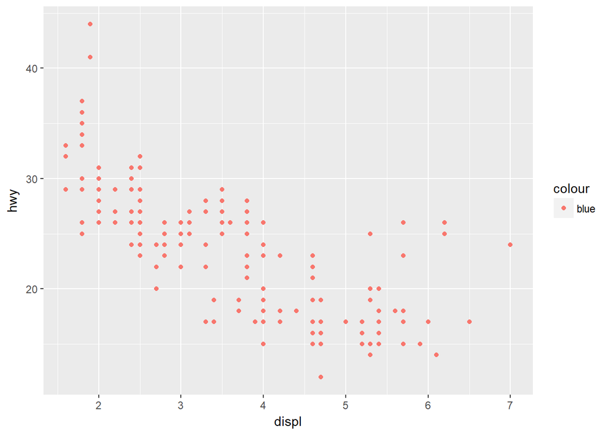

```r
ggplot(data = mpg) +
  geom_point(mapping = aes(x = displ, y = hwy, color = "blue"))
```

2. The categorical variables included in the dataset mpg, include: manufacturer, model, trans, drv, fl, and class. The continuous variables included are: displ, year, cyl, cty, and hwy
3. A plot of displ vs. cty in blue color with a size of 5 is shown below. Mapping continuous variables allows for overlapping/same data points, whereas every point in a categorical datat set, when plotted, is discrete (i.e. no overlapping)

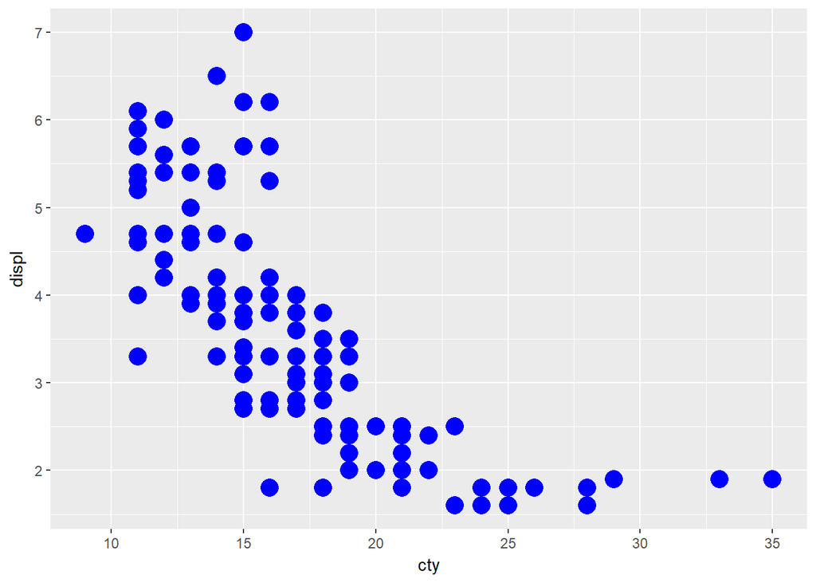

```r
ggplot(data = mpg) +
  geom_point(mapping = aes(x = cty, y = displ), color = "blue", size = 5)
```

4. Adding another aes() changes the name of the axes but does not change the actual plotted data

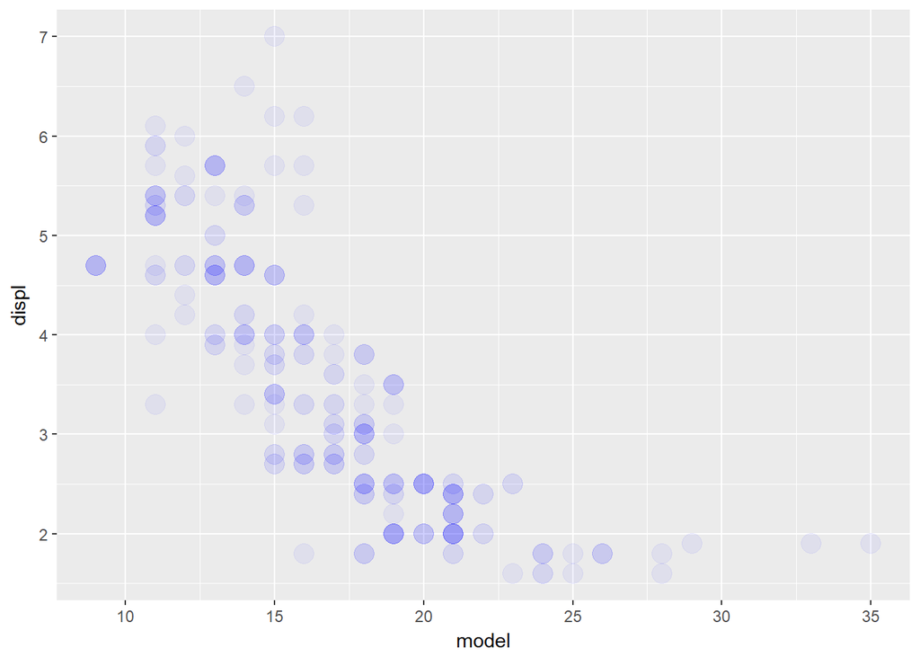

```r
ggplot(data = mpg) +
  geom_point(mapping = aes(x = cty, y = displ), color = "blue", size = 5, alpha = 1/20) +
  aes(x = model, y = displ)
```

5. The stroke aesthetic allows the user to modify the width of the border of plotted shapes. It only works for shapes that have a border.
6. An error message occurs when you try to map an aesthetic other than a variable name.